# A SQL demo: designing a relational database model: Unesco World Heritage Cultural Sites

Author

Beata Sirowy

The task is to design a database model representing flat data across multiple linked tables using “third-normal form” (3NF), i.e. columns that have vertical duplication need to be placed in their own table and linked into the main table using a foreign key.

**Third normal form** (**3NF**) is a database schema design approach for relational databases which uses normalizing principles to reduce the duplication of data, avoid data anomalies, ensure referential integrity, and simplify data management. It was defined in 1971 by Edgar F. Codd, an English computer scientist who invented the relational model for database management. (Wikipedia)

The document is created in Quarto accessed from RStudio connected to a locally hosted PostgreSQL database.

## 1. Loading libraries

```r
library(tidyverse)
library(DBI)
library(RPostgres)
library(dbplyr)
```

## 2. Establishing a database connection (PostgreSQL)

I use RPostgres package to connent to a locally hosted PostgreSQL database.

```r
con <- DBI::dbConnect(
  RPostgres::Postgres(),
  dbname = 'postgres',
  host = 'localhost',
  port = 5432,
  user = 'postgres',
  password = 'abcd'
)
```

## 3. Data

This is a preview of the original csv table

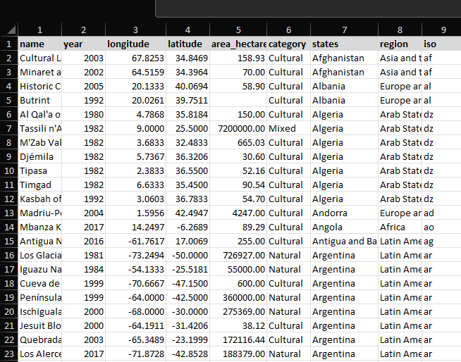

## 4. Database design

The file includes following columns:

name

year

longitude

latitude

area_hectares

**category**

**states**

**region**

**ISO**

The column names written in bold include a lot of vertical replication, which needs to be eliminated - the data will be moved to separate tables.

The data model will include 5 linked tables:

The main table - including data that is not vertically replicated in the original csv file

1. site (name, year. longitude, latitude, area_hectares)

4 tables including dtat that is vertically replicated

2. category
3. state
4. region
5. ISO

### a. Creating a data model diagram

The diagram is created with drawSQL tool

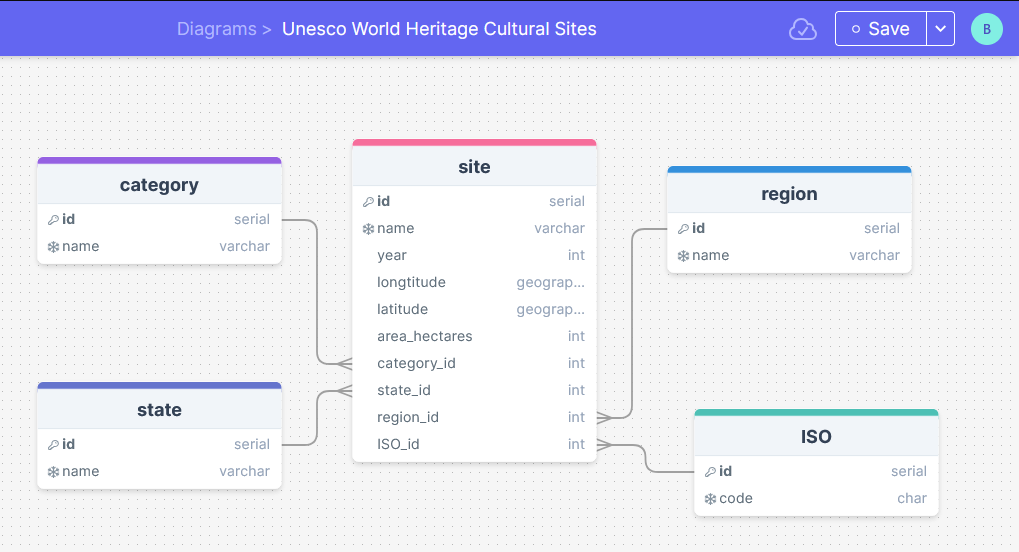

### b. Creating tables

```sql
CREATE TABLE category (
id SERIAL,
name VARCHAR(64) UNIQUE NOT NULL,
PRIMARY KEY(id)
);
```

```sql
CREATE TABLE state(
id SERIAL,
name VARCHAR(64) UNIQUE NOT NULL,
PRIMARY KEY(id)
);
```

```sql
CREATE TABLE region (
id SERIAL,
name VARCHAR(64) UNIQUE NOT NULL,
PRIMARY KEY(id)
);
```

```sql
CREATE TABLE ISO (
id SERIAL,
code CHAR(4) UNIQUE,
PRIMARY KEY(id)
);
```

```sql
CREATE TABLE site (
id SERIAL,
name VARCHAR(256) UNIQUE NOT NULL,
year NUMERIC,
longtitude NUMERIc,
latitude NUMERIC,
area_hectares NUMERIC,
category_id INTEGER REFERENCES category(id) ON DELETE CASCADE,
state_id INTEGER REFERENCES state(id) ON DELETE CASCADE,
region_id INTEGER REFERENCES region(id) ON DELETE CASCADE,
ISO_id INTEGER REFERENCES ISO(id) ON DELETE CASCADE,
PRIMARY KEY(id)
);
```

```sql
SELECT * FROM site;
```

0 records

| id | name | year | longtitude | latitude | area_hectares | category_id | state_id | region_id | iso_id |
| --- | --- | --- | --- | --- | --- | --- | --- | --- | --- |

Here are table details (accessed with command from psql shell):

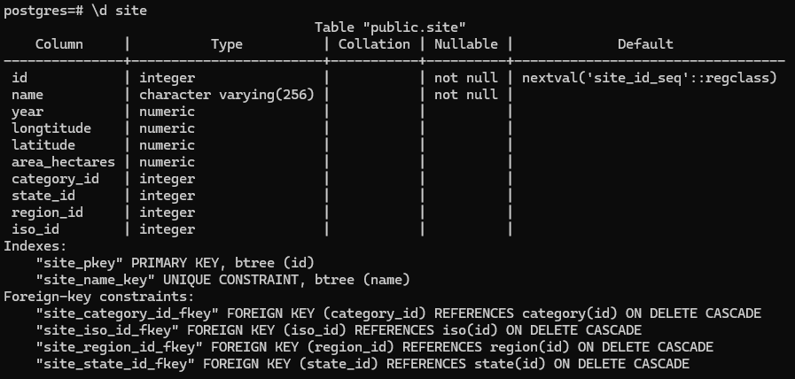

We also create a working table - a temporary “container” for all data imported from the csv file (raw_unesco). This table will be used for further operations in SQL and then discarded.

```sql
CREATE TABLE raw_unesco (
name VARCHAR(1024)UNIQUE NOT NULL,
year INTEGER,
longtitude NUMERIC,
latitude NUMERIC,
area_hectares NUMERIC,
category VARCHAR(64),
states VARCHAR (128),
region VARCHAR (128),
ISO char(4),
category_id INTEGER,
state_id INTEGER,
region_id INTEGER,
ISO_id INTEGER
);
```

### c. Importing data into tables

```sql
COPY raw_unesco(name, year, longtitude, latitude, area_hectares, category, states, region, ISO)
FROM  'D:\Datasets\whc-sites-2018-reduced.csv'
WITH DELIMITER ',' CSV HEADER;
```

```sql
INSERT INTO category (name)
SELECT DISTINCT category FROM raw_unesco;
```

```sql
SELECT * FROM category;
```

3 records

| id | name |
| --- | --- |
| 1 | Cultural |
| 2 | Mixed |
| 3 | Natural |

```sql
INSERT INTO state (name)
SELECT DISTINCT states FROM raw_unesco;
```

```sql
SELECT * FROM state;
```

Displaying records 1 - 10

| id | name |
| --- | --- |
| 1 | Indonesia |
| 2 | Bangladesh |
| 3 | Jerusalem (Site proposed by Jordan) |
| 4 | Iran (Islamic Republic of) |
| 5 | Kiribati |
| 6 | Cameroon |
| 7 | Luxembourg |
| 8 | Sweden |
| 9 | Viet Nam |
| 10 | Uganda |

```sql
INSERT INTO region (name)
SELECT DISTINCT region FROM raw_unesco;
```

```sql
SELECT * FROM region;
```

5 records

| id | name |
| --- | --- |
| 1 | Asia and the Pacific |
| 2 | Arab States |
| 3 | Europe and North America |
| 4 | Latin America and the Caribbean |
| 5 | Africa |

```sql
INSERT INTO ISO (code)
SELECT DISTINCT ISO
FROM raw_unesco;
```

```sql
Select * FROM ISO;
```

Displaying records 1 - 10

| id | code |
| --- | --- |
| 1 | sm |
| 2 | fj |
| 3 | bd |
| 4 | np |
| 5 | vu |
| 6 | fr |
| 7 | bh |
| 8 | sk |
| 9 | pa |
| 10 | NA |

Next, we update the “raw_unesco” table adding category_id, state_id, region_id, and ISO:_id column. The values in these columns will be taken from newly created tables (category, state, region, ISO) ,

```sql
UPDATE raw_unesco
SET category_id = (SELECT category.id FROM category WHERE category.name = raw_unesco.category);
```

```sql
UPDATE raw_unesco
SET region_id = (SELECT region.id FROM region WHERE region.name = raw_unesco.region);
```

```sql
UPDATE raw_unesco
SET state_id = (SELECT state.id FROM state WHERE state.name = raw_unesco.states);
```

```sql
UPDATE raw_unesco
SET ISO_id = (SELECT ISO.id FROM ISO WHERE ISO.code = raw_unesco.ISO);
```

As we can see the columns in the “raw_unesco” have been updated.

```sql
SELECT name, category_id, state_id, region_id, iso_id
FROM raw_unesco
WHERE states = 'Sweden';
```

Displaying records 1 - 10

| name | category_id | state_id | region_id | iso_id |
| --- | --- | --- | --- | --- |
| Birka and Hovgården | 1 | 8 | 3 | 37 |
| Engelsberg Ironworks | 1 | 8 | 3 | 37 |
| Rock Carvings in Tanum | 1 | 8 | 3 | 37 |
| Skogskyrkogården | 1 | 8 | 3 | 37 |
| Royal Domain of Drottningholm | 1 | 8 | 3 | 37 |
| Hanseatic Town of Visby | 1 | 8 | 3 | 37 |
| Church Town of Gammelstad, Luleå | 1 | 8 | 3 | 37 |
| Laponian Area | 2 | 8 | 3 | 37 |
| Naval Port of Karlskrona | 1 | 8 | 3 | 37 |
| Agricultural Landscape of Southern Öland | 1 | 8 | 3 | 37 |

[figure not shown]

In the next step I copy the values from categoryt_id, state_id, region_id, and ISO_id column in the “raw_unesco” table into the “site” table - the ultimate destination table.

```sql
INSERT INTO site (
name,
year,
longtitude,
latitude,
area_hectares,
category_id,
state_id,
region_id,
ISO_id)
SELECT
name,
year,
longtitude,
latitude,
area_hectares,
category_id,
state_id,
region_id,
ISO_id
FROM raw_unesco;
```

```sql
SELECT * FROM site
WHERE name LIKE 'A%'
LIMIT 10;
```

Displaying records 1 - 10

| id | name | year | longtitude | latitude | area_hectares | category_id | state_id | region_id | iso_id |
| --- | --- | --- | --- | --- | --- | --- | --- | --- | --- |
| 9 | Al Qal’a of Beni Hammad | 1980 | 4.7868 | 35.8184 | 150.00 | 1 | 33 | 2 | 69 |
| 19 | Antigua Naval Dockyard and Related Archaeological Sites | 2016 | -61.7617 | 17.0069 | 255.00 | 1 | 162 | 4 | 117 |
| 47 | Australian Fossil Mammal Sites (Riversleigh / Naracoorte) | 1994 | 138.7167 | -19.0833 | 10326.00 | 3 | 63 | 1 | 78 |
| 55 | Australian Convict Sites | 2010 | 150.9944 | -33.3783 | 1502.51 | 1 | 63 | 1 | 78 |
| 72 | Architectural, Residential and Cultural Complex of the Radziwill Family at Nesvizh | 2005 | 26.6914 | 53.2228 | 0.00 | 1 | 57 | 3 | 110 |
| 104 | Atlantic Forest South-East Reserves | 1999 | -48.0000 | -24.1667 | 468193.00 | 3 | 136 | 4 | 72 |
| 119 | Ancient City of Nessebar | 1983 | 27.7300 | 42.6561 | 27.10 | 1 | 144 | 3 | 15 |
| 125 | Angkor | 1992 | 103.8333 | 13.4333 | 40100.00 | 1 | 16 | 1 | 34 |
| 165 | Ancient Building Complex in the Wudang Mountains | 1994 | 111.0000 | 32.4667 | 0.00 | 1 | 55 | 1 | 22 |
| 170 | Ancient City of Ping Yao | 1997 | 112.1544 | 37.2014 | 245.62 | 1 | 55 | 1 | 22 |

[figure not shown]

We can now discard the temporary table “raw_unesco”

```sql
DROP TABLE raw_unesco;
```

### d. Joining tables

We can join tables to display the combined data

```sql
SELECT site.name, site.year, category.name AS category, state.name AS state, region.name AS region, ISO.code AS ISO
FROM site
JOIN category ON category.id = site.category_id
JOIN state ON state.id = site.state_id
JOIN region ON region.id = site.region_id
JOIN ISO ON ISO.id = site.iso_id
LIMIT 10
;
```

Displaying records 1 - 10

| name | year | category | state | region | iso |
| --- | --- | --- | --- | --- | --- |
| Royal Palaces of Abomey | 1985 | Cultural | Benin | Africa | bj |
| Wadi Al-Hitan (Whale Valley) | 2005 | Natural | Egypt | Arab States | eg |
| Taxila | 1980 | Cultural | Pakistan | Asia and the Pacific | pk |
| Robben Island | 1999 | Cultural | South Africa | Africa | za |
| Cultural Landscape and Archaeological Remains of the Bamiyan Valley | 2003 | Cultural | Afghanistan | Asia and the Pacific | af |
| Minaret and Archaeological Remains of Jam | 2002 | Cultural | Afghanistan | Asia and the Pacific | af |
| Historic Centres of Berat and Gjirokastra | 2005 | Cultural | Albania | Europe and North America | al |
| Butrint | 1992 | Cultural | Albania | Europe and North America | al |
| Al Qal’a of Beni Hammad | 1980 | Cultural | Algeria | Arab States | dz |
| Tassili n’Ajjer | 1982 | Mixed | Algeria | Arab States | dz |

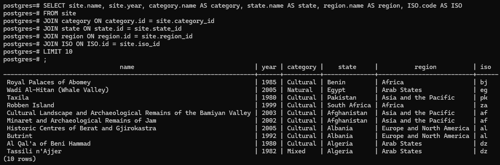